# Case Study 2 Analysis

Kosi Okeke

2024-04-21

# EDA

We would like to do beginner EDA on variables to explore if they are related to either Attrition or MonthlyIncome.

But first…

```r
#Necessary Libraries (ongoing list that may update)
library(dplyr)
```

```r
library(ggplot2)
library(GGally)
library(tidyr)
library(caret)
library(shiny)
library(class)
library(caTools)
library(e1071)
```

```r
#Load in the dataset. It is a survey of attrition at a company
attrition = read.csv(choose.files(), header = TRUE)
str(attrition)
```

```
## 'data.frame':    870 obs. of  36 variables:
##  $ ID                      : int  1 2 3 4 5 6 7 8 9 10 ...
##  $ Age                     : int  32 40 35 32 24 27 41 37 34 34 ...
##  $ Attrition               : chr  "No" "No" "No" "No" ...
##  $ BusinessTravel          : chr  "Travel_Rarely" "Travel_Rarely" "Travel_Frequently" "Travel_Rarely" ...
##  $ DailyRate               : int  117 1308 200 801 567 294 1283 309 1333 653 ...
##  $ Department              : chr  "Sales" "Research & Development" "Research & Development" "Sales" ...
##  $ DistanceFromHome        : int  13 14 18 1 2 10 5 10 10 10 ...
##  $ Education               : int  4 3 2 4 1 2 5 4 4 4 ...
##  $ EducationField          : chr  "Life Sciences" "Medical" "Life Sciences" "Marketing" ...
##  $ EmployeeCount           : int  1 1 1 1 1 1 1 1 1 1 ...
##  $ EmployeeNumber          : int  859 1128 1412 2016 1646 733 1448 1105 1055 1597 ...
##  $ EnvironmentSatisfaction : int  2 3 3 3 1 4 2 4 3 4 ...
##  $ Gender                  : chr  "Male" "Male" "Male" "Female" ...
##  $ HourlyRate              : int  73 44 60 48 32 32 90 88 87 92 ...
```

[output cut: 22 more lines]

```r
View(attrition)
summary(attrition)
```

```
##        ID             Age         Attrition         BusinessTravel
##  Min.   :  1.0   Min.   :18.00   Length:870         Length:870
##  1st Qu.:218.2   1st Qu.:30.00   Class :character   Class :character
##  Median :435.5   Median :35.00   Mode  :character   Mode  :character
##  Mean   :435.5   Mean   :36.83
##  3rd Qu.:652.8   3rd Qu.:43.00
##  Max.   :870.0   Max.   :60.00
##    DailyRate       Department        DistanceFromHome   Education
##  Min.   : 103.0   Length:870         Min.   : 1.000   Min.   :1.000
##  1st Qu.: 472.5   Class :character   1st Qu.: 2.000   1st Qu.:2.000
##  Median : 817.5   Mode  :character   Median : 7.000   Median :3.000
##  Mean   : 815.2                      Mean   : 9.339   Mean   :2.901
##  3rd Qu.:1165.8                      3rd Qu.:14.000   3rd Qu.:4.000
##  Max.   :1499.0                      Max.   :29.000   Max.   :5.000
##  EducationField     EmployeeCount EmployeeNumber   EnvironmentSatisfaction
##  Length:870         Min.   :1     Min.   :   1.0   Min.   :1.000
##  Class :character   1st Qu.:1     1st Qu.: 477.2   1st Qu.:2.000
##  Mode  :character   Median :1     Median :1039.0   Median :3.000
##                     Mean   :1     Mean   :1029.8   Mean   :2.701
##                     3rd Qu.:1     3rd Qu.:1561.5   3rd Qu.:4.000
##                     Max.   :1     Max.   :2064.0   Max.   :4.000
##     Gender            HourlyRate     JobInvolvement     JobLevel
##  Length:870         Min.   : 30.00   Min.   :1.000   Min.   :1.000
##  Class :character   1st Qu.: 48.00   1st Qu.:2.000   1st Qu.:1.000
##  Mode  :character   Median : 66.00   Median :3.000   Median :2.000
##                     Mean   : 65.61   Mean   :2.723   Mean   :2.039
##                     3rd Qu.: 83.00   3rd Qu.:3.000   3rd Qu.:3.000
##                     Max.   :100.00   Max.   :4.000   Max.   :5.000
##    JobRole          JobSatisfaction MaritalStatus      MonthlyIncome
##  Length:870         Min.   :1.000   Length:870         Min.   : 1081
##  Class :character   1st Qu.:2.000   Class :character   1st Qu.: 2840
##  Mode  :character   Median :3.000   Mode  :character   Median : 4946
##                     Mean   :2.709                      Mean   : 6390
##                     3rd Qu.:4.000                      3rd Qu.: 8182
##                     Max.   :4.000                      Max.   :19999
##   MonthlyRate    NumCompaniesWorked    Over18            OverTime
##  Min.   : 2094   Min.   :0.000      Length:870         Length:870
##  1st Qu.: 8092   1st Qu.:1.000      Class :character   Class :character
##  Median :14074   Median :2.000      Mode  :character   Mode  :character
##  Mean   :14326   Mean   :2.728
```

[output cut: 15 more lines]

```
##  Max.   :3.0000   Max.   :40.00     Max.   :6.000         Max.   :4.000
##  YearsAtCompany   YearsInCurrentRole YearsSinceLastPromotion
##  Min.   : 0.000   Min.   : 0.000     Min.   : 0.000
##  1st Qu.: 3.000   1st Qu.: 2.000     1st Qu.: 0.000
##  Median : 5.000   Median : 3.000     Median : 1.000
##  Mean   : 6.962   Mean   : 4.205     Mean   : 2.169
##  3rd Qu.:10.000   3rd Qu.: 7.000     3rd Qu.: 3.000
##  Max.   :40.000   Max.   :18.000     Max.   :15.000
##  YearsWithCurrManager
##  Min.   : 0.00
##  1st Qu.: 2.00
##  Median : 3.00
##  Mean   : 4.14
##  3rd Qu.: 7.00
##  Max.   :17.00
```

## Beginner EDA

```r
##Let's do some beginner EDA on our variables:
# Visualize distribution of Age
# Calculate mean and median of Age
mean_age <- mean(attrition$Age)
median_age <- median(attrition$Age)
sd(attrition$Age)
```

```
## [1] 8.92595
```

```r
min(attrition$Age)
```

```
## [1] 18
```

```r
max(attrition$Age)
```

```
## [1] 60
```

We see that our youngest employee is 18 while our oldest is 60. We can view the distribution in the next chunk.

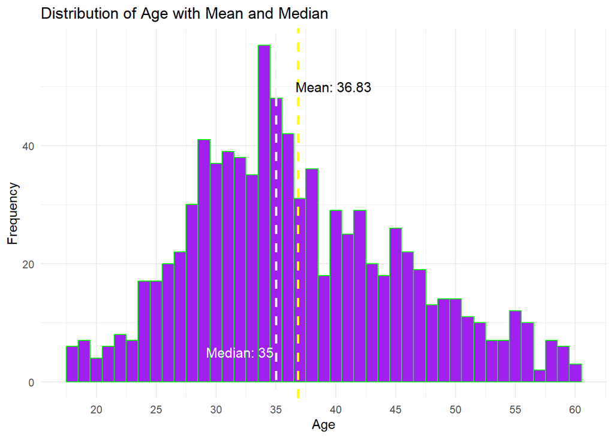

```r
# Visualize distribution of Age with mean and median lines
ggplot(data = attrition, aes(x = Age)) +
  geom_histogram(binwidth = 1, fill = "purple", color = "green") +
  geom_vline(xintercept = mean_age, color = "yellow", linetype = "dashed", size = 1) +  # Add mean line
  geom_vline(xintercept = median_age, color = "white", linetype = "dashed", size = 1) +  # Add median line
  annotate("text", x = mean_age + 3, y = 50, label = paste("Mean:", round(mean_age, 2)), color = "black", size = 4) +  # Add mean label
  annotate("text", x = median_age - 3, y = 5, label = paste("Median:", round(median_age, 2)), color = "White", size = 4) +  # Add median label
  labs(title = "Distribution of Age with Mean and Median",
       x = "Age",
       y = "Frequency") +
  scale_x_continuous(breaks = seq(0, max(attrition$Age), by = 5)) +  # Adjust x-axis breaks
  theme_minimal()
```

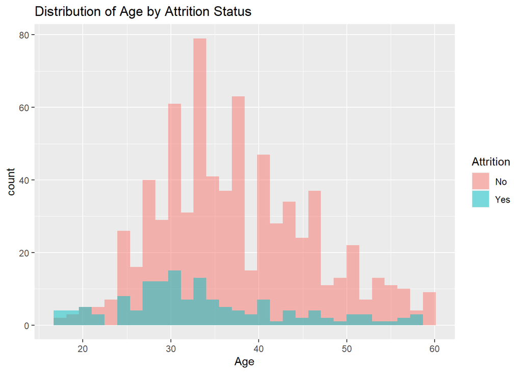

```r
# Explore relationship between Age and Attrition
ggplot(attrition, aes(x = Age, fill = Attrition)) +
  geom_histogram(position = "identity", alpha = 0.5, bins = 30) +
  labs(title = "Distribution of Age by Attrition Status")
```

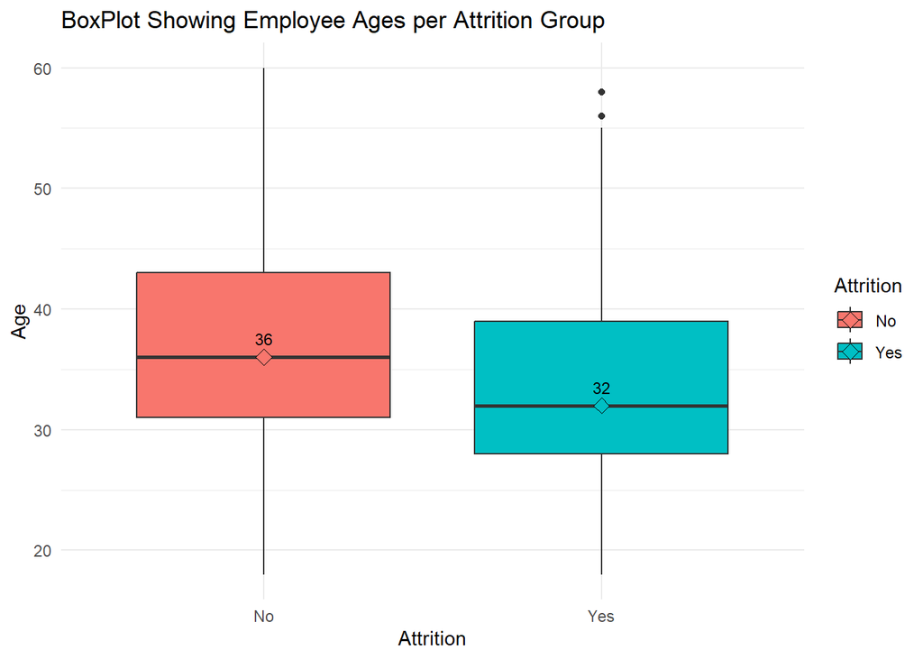

```r
# Avg age for attrition looks to be around the 30s.

# Age is one of our factors for Attrition.
ggplot(attrition, aes(x = Attrition, y = Age, fill = Attrition)) +
  geom_boxplot() +
  stat_summary(fun = median, geom = "point", shape = 23, size = 3, color = "black") +  # Add mean points
  stat_summary(fun = median, geom = "text", aes(label = round(..y.., 1)), vjust = -1.0, size = 3, color = "black") +  # Add mean labels
  labs(x = "Attrition", y = "Age", fill = "Attrition") +
  ggtitle("BoxPlot Showing Employee Ages per Attrition Group") +
  theme_minimal()
```

**Age** is one of our factors for Attrition.

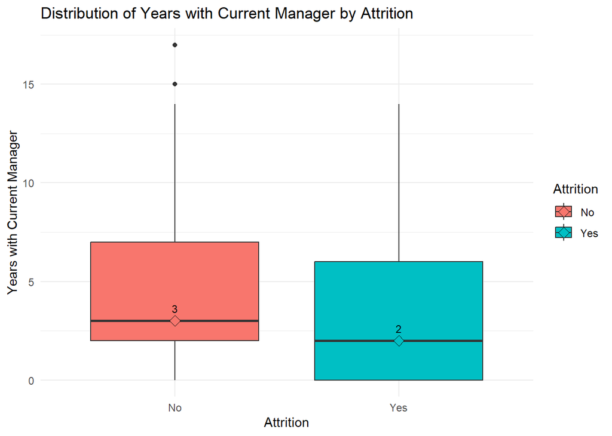

```r
ggplot(attrition, aes(x = Attrition, y = YearsWithCurrManager, fill = Attrition)) +
       geom_boxplot() +
       stat_summary(fun = median, geom = "point", shape = 23, size = 3, color = "black") +  # Add mean points
       stat_summary(fun = median, geom = "text", aes(label = round(..y.., 1)), vjust = -1.0, size = 3, color = "black") +  # Add mean labels
       labs(x = "Attrition", y = "Years with Current Manager", fill = "Attrition") +
       ggtitle("Distribution of Years with Current Manager by Attrition") +
       theme_minimal()
```

```r
t.test(YearsWithCurrManager ~ Attrition, data = attrition) # Mean of
```

```
##
##  Welch Two Sample t-test
##
## data:  YearsWithCurrManager by Attrition
## t = 4.6826, df = 209.75, p-value = 5.084e-06
## alternative hypothesis: true difference in means between group No and group Yes is not equal to 0
## 95 percent confidence interval:
##  0.8262439 2.0277679
## sample estimates:
##  mean in group No mean in group Yes
##          4.369863          2.942857
```

```r
# no group is 4.37, mean of yes is 2.94. No > Yes.
chisq.test(table(attrition$YearsWithCurrManager, attrition$Attrition))
```

```
##
##  Pearson's Chi-squared test
##
## data:  table(attrition$YearsWithCurrManager, attrition$Attrition)
## X-squared = 43.229, df = 16, p-value = 0.0002581
```

```r
# When we do the same for YearsWithCurrManager we see both tests have extremely
# low p-values. So we know there's a reason to believe the mean difference b/n
# No and Yes groups for YearsWithCurrManager is different than 0 (nonzero).
```

The mean of No Attrition group is **4.37 years**.

Mean of Yes Attrition is **2.94**.

Our p-value of **5.084e-06** let’s us know the No Group’s mean is greater than Yes Group’s (nonzero mean between the groups is positive).

Running a Chi-Squared test on **YearsWCurrentManager** and Attrition we receive an extremely low p-value letting us know the variables are associated.

```r
# Calculate attrition rates for each level of JobInvolvement
attrition_rates <- attrition %>%
  group_by(JobInvolvement, Attrition) %>%
  summarize(count = n()) %>%
  group_by(JobInvolvement) %>%
  mutate(attrition_rate = sum(count[Attrition == "Yes"]) / sum(count) * 100)
```

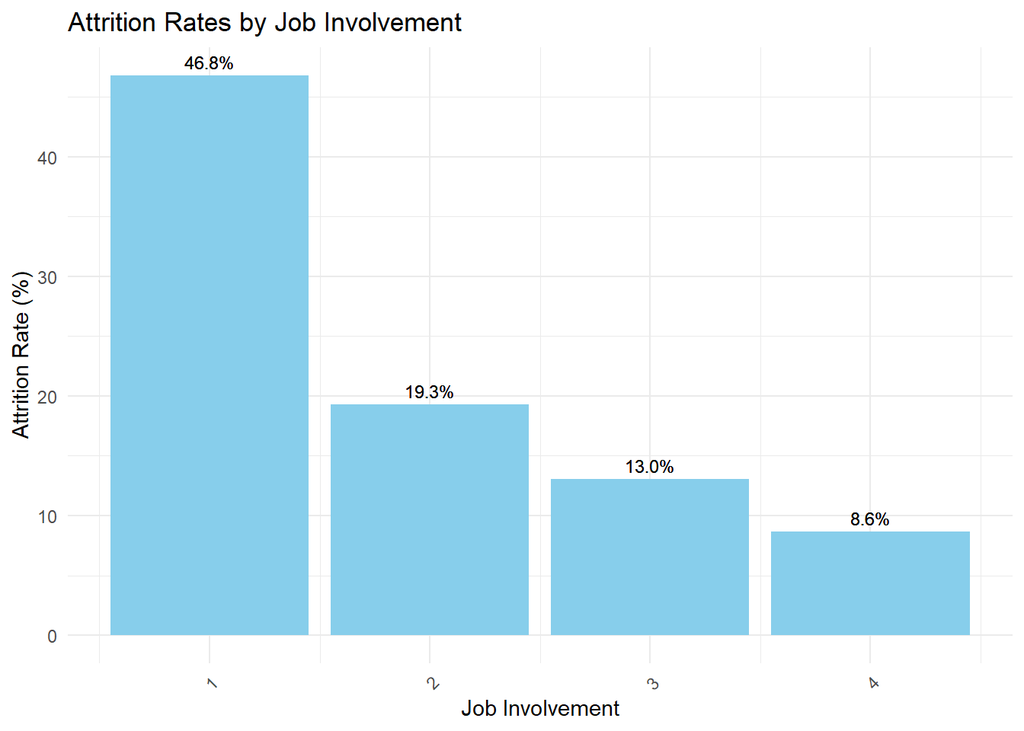

```r
# Create a bar plot of attrition rates by JobInvolvement
ggplot(attrition_rates, aes(x = JobInvolvement, y = attrition_rate, fill = JobInvolvement)) +
  geom_bar(stat = "identity", position = "dodge", fill = "skyblue") +
  geom_text(aes(label = sprintf("%.1f%%", attrition_rate)), vjust = -0.5, size = 3) +  # Add text annotations
  labs(title = "Attrition Rates by Job Involvement",
       x = "Job Involvement",
       y = "Attrition Rate (%)") +
  theme_minimal() +
  theme(axis.text.x = element_text(angle = 45, hjust = 1))
```

```r
# Job involvement obviously correlates with attrition rates. As job involvement
# increases, the rate of attrition decreases. People who feel more involved don't
# want to quit or leave the job.
```

We can see intuitively that **JobInvolvement** correlates with Attrition. As Job Involvement increases levels, Attrition Rate goes down.

This can mean that as employees feel more involved in their job, they will want to stick around and continue working for the company.

Now that we have found the factors we believe affect Attrition the most, let’s build a prediction model.

# Prediction Models

We are going to build two predictive models:

1. Choosing b/n either a kNN classifier model or a Naive-Bayes model to see if we can predict who will fall in the Attrition group or not on a competition dataset (Seeking Specificity > 60% and a Sensitivity > 60%).

2. A linear regression model capable of prediciting MonthlyIncome on the competition dataset (seeking an RMSE < $3000).

## Naive-Bayes

```r
# Preprocess the data
attrition$Education <- as.factor(attrition$Education)
attrition$EnvironmentSatisfaction <- as.factor(attrition$EnvironmentSatisfaction)
attrition$JobInvolvement <- as.factor(attrition$JobInvolvement)
attrition$JobLevel <- as.factor(attrition$JobLevel)
attrition$JobSatisfaction <- as.factor(attrition$JobSatisfaction)
attrition$PerformanceRating <- as.factor(attrition$PerformanceRating)
attrition$RelationshipSatisfaction <- as.factor(attrition$RelationshipSatisfaction)
attrition$StockOptionLevel <- as.factor(attrition$StockOptionLevel)
attrition$WorkLifeBalance <- as.factor(attrition$WorkLifeBalance)
attrition <- attrition[, !names(attrition) %in% "EmployeeCount"]
attrition <- attrition[, !names(attrition) %in% "EmployeeNumber"]
# Identify character columns
char_columns <- sapply(attrition, is.character)
# Convert character columns to factors
attrition[char_columns] <- lapply(attrition[char_columns], as.factor)
```

80/20 random Train and Test split of the data

```r
# Split the data into training and testing sets
set.seed(123)  # Set seed for reproducibility
split <- sample.split(attrition$Attrition, SplitRatio = 0.8)
train_data <- attrition[split, ]
test_data <- attrition[!split, ]

str(train_data) # We see Over18 and StandardHours have only 1 value throughout the rows
```

```
## 'data.frame':    696 obs. of  34 variables:
##  $ ID                      : int  1 2 3 6 7 9 10 12 13 14 ...
##  $ Age                     : int  32 40 35 27 41 34 34 28 35 30 ...
##  $ Attrition               : Factor w/ 2 levels "No","Yes": 1 1 1 1 1 1 1 1 1 1 ...
##  $ BusinessTravel          : Factor w/ 3 levels "Non-Travel","Travel_Frequently",..: 3 3 2 2 3 3 2 1 3 3 ...
##  $ DailyRate               : int  117 1308 200 294 1283 1333 653 280 950 202 ...
##  $ Department              : Factor w/ 3 levels "Human Resources",..: 3 2 2 2 2 3 2 1 2 3 ...
##  $ DistanceFromHome        : int  13 14 18 10 5 10 10 1 7 2 ...
##  $ Education               : Factor w/ 5 levels "1","2","3","4",..: 4 3 2 2 5 4 4 2 3 1 ...
##  $ EducationField          : Factor w/ 6 levels "Human Resources",..: 2 4 2 2 4 2 6 2 5 6 ...
##  $ EnvironmentSatisfaction : Factor w/ 4 levels "1","2","3","4": 2 3 3 4 2 3 4 3 3 3 ...
##  $ Gender                  : Factor w/ 2 levels "Female","Male": 2 2 2 2 2 1 2 2 2 2 ...
##  $ HourlyRate              : int  73 44 60 32 90 87 92 43 59 72 ...
##  $ JobInvolvement          : Factor w/ 4 levels "1","2","3","4": 3 2 3 3 4 3 2 3 3 3 ...
##  $ JobLevel                : Factor w/ 5 levels "1","2","3","4",..: 2 5 3 3 1 1 2 1 3 1 ...
```

[output cut: 20 more lines]

```r
# Remove variables with only one level
train_data_clean <- train_data[, sapply(train_data, function(x) length(unique(x)) > 1)]
```

```r
# Build the Naive Bayes model
nb_model <- naiveBayes(Attrition ~ . - ID, data = train_data_clean)
nb_model
```

```
##
## Naive Bayes Classifier for Discrete Predictors
##
## Call:
## naiveBayes.default(x = X, y = Y, laplace = laplace)
##
## A-priori probabilities:
## Y
##        No       Yes
## 0.8390805 0.1609195
##
## Conditional probabilities:
##      Age
## Y         [,1]     [,2]
##   No  37.51712 8.773090
##   Yes 33.97321 9.906281
##
##      BusinessTravel
## Y     Non-Travel Travel_Frequently Travel_Rarely
##   No  0.11815068        0.16780822    0.71404110
##   Yes 0.09821429        0.24107143    0.66071429
##
##      DailyRate
## Y         [,1]     [,2]
##   No  832.1918 400.0033
##   Yes 797.3304 407.2768
##
##      Department
## Y     Human Resources Research & Development      Sales
##   No       0.04109589             0.67465753 0.28424658
##   Yes      0.03571429             0.53571429 0.42857143
##
##      DistanceFromHome
## Y          [,1]     [,2]
##   No   9.344178 8.081894
##   Yes 11.035714 8.806149
##
##      Education
## Y              1          2          3          4          5
##   No  0.10445205 0.21404110 0.36986301 0.27910959 0.03253425
```

[output cut: 118 more lines]

```
##
##      YearsInCurrentRole
## Y         [,1]     [,2]
##   No  4.575342 3.727577
##   Yes 2.919643 3.422602
##
##      YearsSinceLastPromotion
## Y         [,1]     [,2]
##   No  2.176370 3.108345
##   Yes 2.169643 3.596516
##
##      YearsWithCurrManager
## Y         [,1]     [,2]
##   No  4.482877 3.589538
##   Yes 3.000000 3.339634
```

```r
# Make predictions on the test data
predictions <- predict(nb_model, test_data)
# We will need to do the same on the dataset professor gave us eventually

# Assess model performance
confusion_matrix <- table(predictions, test_data$Attrition)
confusion_matrix
```

```
##
## predictions  No Yes
##         No  125   9
##         Yes  21  19
```

```r
accuracy <- sum(diag(confusion_matrix)) / sum(confusion_matrix)
accuracy
```

```
## [1] 0.8275862
```

```r
precision <- confusion_matrix[2, 2] / sum(confusion_matrix[, 2])
precision
```

```
## [1] 0.6785714
```

```r
recall <- confusion_matrix[2, 2] / sum(confusion_matrix[2, ]) #also known as sensitivity
recall
```

```
## [1] 0.475
```

```r
f1_score <- 2 * (precision * recall) / (precision + recall)
f1_score
```

```
## [1] 0.5588235
```

We see we can definitely improve on our model. Let’s try using thresholds.

```r
# Obtain predicted probabilities
predicted_probabilities <- predict(nb_model, test_data, type = "raw")

# Choose a new threshold (e.g., 0.7 is what we settled on after using different numbers)
new_threshold <- 0.70

# Assign class labels based on the new threshold
predicted_labels <- ifelse(predicted_probabilities[, "Yes"] >= new_threshold, "Yes", "No")

# Calculate confusion matrix
confusion_matrix <- table(predicted_labels, test_data$Attrition)
confusion_matrix
```

```
##
## predicted_labels  No Yes
##              No  139  12
##              Yes   7  16
```

```r
accuracy <- sum(diag(confusion_matrix)) / sum(confusion_matrix)
accuracy
```

```
## [1] 0.8908046
```

```r
precision <- confusion_matrix[2, 2] / sum(confusion_matrix[, 2])
precision
```

```
## [1] 0.5714286
```

```r
recall <- confusion_matrix[2, 2] / sum(confusion_matrix[2, ]) #also known as sensitivity
recall # Much greater than our 60% from rubric
```

```
## [1] 0.6956522
```

```r
f1_score <- 2 * (precision * recall) / (precision + recall)
f1_score
```

```
## [1] 0.627451
```

First is accuracy. Then Precision. Then Recall/Sensitivity. Then an F1 Score.

Let’s run the model for the new submission data set.

```r
attrition_test = read.csv(choose.files(), header = TRUE)

# Preprocess the data
attrition_test$Education <- as.factor(attrition_test$Education)
attrition_test$EnvironmentSatisfaction <- as.factor(attrition_test$EnvironmentSatisfaction)
attrition_test$JobInvolvement <- as.factor(attrition_test$JobInvolvement)
attrition_test$JobLevel <- as.factor(attrition_test$JobLevel)
attrition_test$JobSatisfaction <- as.factor(attrition_test$JobSatisfaction)
attrition_test$PerformanceRating <- as.factor(attrition_test$PerformanceRating)
attrition_test$RelationshipSatisfaction <- as.factor(attrition_test$RelationshipSatisfaction)
attrition_test$StockOptionLevel <- as.factor(attrition_test$StockOptionLevel)
attrition_test$WorkLifeBalance <- as.factor(attrition_test$WorkLifeBalance)
attrition_test <- attrition_test[, !names(attrition_test) %in% "EmployeeCount"]
attrition_test <- attrition_test[, !names(attrition_test) %in% "EmployeeNumber"]
# Identify character columns
char_columns <- sapply(attrition_test, is.character)
# Convert character columns to factors
attrition_test[char_columns] <- lapply(attrition_test[char_columns], as.factor)

testing_clean <- attrition_test[, sapply(attrition_test, function(x) length(unique(x)) > 1)]
```

Data is cleaned. Now to make the CSV.

```r
# TESTING ON THE NEW DATASET
predicted_probabilities <- predict(nb_model, testing_clean, type = "raw")
# Choose a new threshold (e.g., 0.4)
new_threshold <- 0.70
# Assign class labels based on the new threshold
predicted_labels <- ifelse(predicted_probabilities[, "Yes"] >= new_threshold, "Yes", "No")

testing_clean$Predicted_Attrition <- predicted_labels

# NOW WE CREATE OUR SUBMISSION DATAFRAME AND CSV:
Case2PredictionsOKEKEAttrition = data.frame(ID = testing_clean$ID,
                                            Attrition = testing_clean$Predicted_Attrition)
View(Case2PredictionsOKEKEAttrition)
# Write dataframe to CSV file
write.csv(Case2PredictionsOKEKEAttrition, file = "Case2PredictionsOKEKE Attrition.csv", row.names = FALSE)
```

Submission complete.

## Linear Regression Model

Now we need to build a Linear Regression Model to help predict MonthlyIncome.

```r
### Building a linear regression model to predict "MonthlyIncome" variable
attrition = read.csv(choose.files(), header = TRUE)



# Preprocess the data
attrition$Education <- as.factor(attrition$Education)
attrition$EnvironmentSatisfaction <- as.factor(attrition$EnvironmentSatisfaction)
attrition$JobInvolvement <- as.factor(attrition$JobInvolvement)
attrition$JobLevel <- as.factor(attrition$JobLevel)
attrition$JobSatisfaction <- as.factor(attrition$JobSatisfaction)
attrition$PerformanceRating <- as.factor(attrition$PerformanceRating)
attrition$RelationshipSatisfaction <- as.factor(attrition$RelationshipSatisfaction)
attrition$StockOptionLevel <- as.factor(attrition$StockOptionLevel)
attrition$WorkLifeBalance <- as.factor(attrition$WorkLifeBalance)
attrition <- attrition[, !names(attrition) %in% "EmployeeCount"]
attrition <- attrition[, !names(attrition) %in% "EmployeeNumber"]
# Identify character columns
char_columns <- sapply(attrition, is.character)
# Convert character columns to factors
attrition[char_columns] <- lapply(attrition[char_columns], as.factor)
```

Now let’s make sure we increase the robustness of our model by doing an 80/20 train and test split.

```r
# Split the data into training and testing sets
set.seed(123)  # Set seed for reproducibility
split <- sample.split(attrition$Attrition, SplitRatio = 0.8)
train_data <- attrition[split, ]
test_data <- attrition[!split, ]
```

```r
str(train_data) # We see Over18 and StandardHours have only 1 value throughout the rows
```

```
## 'data.frame':    696 obs. of  34 variables:
##  $ ID                      : int  1 2 3 6 7 9 10 12 13 14 ...
##  $ Age                     : int  32 40 35 27 41 34 34 28 35 30 ...
##  $ Attrition               : Factor w/ 2 levels "No","Yes": 1 1 1 1 1 1 1 1 1 1 ...
##  $ BusinessTravel          : Factor w/ 3 levels "Non-Travel","Travel_Frequently",..: 3 3 2 2 3 3 2 1 3 3 ...
##  $ DailyRate               : int  117 1308 200 294 1283 1333 653 280 950 202 ...
##  $ Department              : Factor w/ 3 levels "Human Resources",..: 3 2 2 2 2 3 2 1 2 3 ...
##  $ DistanceFromHome        : int  13 14 18 10 5 10 10 1 7 2 ...
##  $ Education               : Factor w/ 5 levels "1","2","3","4",..: 4 3 2 2 5 4 4 2 3 1 ...
##  $ EducationField          : Factor w/ 6 levels "Human Resources",..: 2 4 2 2 4 2 6 2 5 6 ...
##  $ EnvironmentSatisfaction : Factor w/ 4 levels "1","2","3","4": 2 3 3 4 2 3 4 3 3 3 ...
##  $ Gender                  : Factor w/ 2 levels "Female","Male": 2 2 2 2 2 1 2 2 2 2 ...
##  $ HourlyRate              : int  73 44 60 32 90 87 92 43 59 72 ...
##  $ JobInvolvement          : Factor w/ 4 levels "1","2","3","4": 3 2 3 3 4 3 2 3 3 3 ...
##  $ JobLevel                : Factor w/ 5 levels "1","2","3","4",..: 2 5 3 3 1 1 2 1 3 1 ...
```

[output cut: 20 more lines]

```r
# Remove variables with only one level
train_data_clean <- train_data[, sapply(train_data, function(x) length(unique(x)) > 1)]

# Check the structure of the cleaned dataset
str(train_data_clean) # We are good to go.
```

```
## 'data.frame':    696 obs. of  32 variables:
##  $ ID                      : int  1 2 3 6 7 9 10 12 13 14 ...
##  $ Age                     : int  32 40 35 27 41 34 34 28 35 30 ...
##  $ Attrition               : Factor w/ 2 levels "No","Yes": 1 1 1 1 1 1 1 1 1 1 ...
##  $ BusinessTravel          : Factor w/ 3 levels "Non-Travel","Travel_Frequently",..: 3 3 2 2 3 3 2 1 3 3 ...
##  $ DailyRate               : int  117 1308 200 294 1283 1333 653 280 950 202 ...
##  $ Department              : Factor w/ 3 levels "Human Resources",..: 3 2 2 2 2 3 2 1 2 3 ...
##  $ DistanceFromHome        : int  13 14 18 10 5 10 10 1 7 2 ...
##  $ Education               : Factor w/ 5 levels "1","2","3","4",..: 4 3 2 2 5 4 4 2 3 1 ...
##  $ EducationField          : Factor w/ 6 levels "Human Resources",..: 2 4 2 2 4 2 6 2 5 6 ...
##  $ EnvironmentSatisfaction : Factor w/ 4 levels "1","2","3","4": 2 3 3 4 2 3 4 3 3 3 ...
##  $ Gender                  : Factor w/ 2 levels "Female","Male": 2 2 2 2 2 1 2 2 2 2 ...
##  $ HourlyRate              : int  73 44 60 32 90 87 92 43 59 72 ...
##  $ JobInvolvement          : Factor w/ 4 levels "1","2","3","4": 3 2 3 3 4 3 2 3 3 3 ...
##  $ JobLevel                : Factor w/ 5 levels "1","2","3","4",..: 2 5 3 3 1 1 2 1 3 1 ...
```

[output cut: 18 more lines]

Our data is much cleaner now. Let’s use forward selection to let variable selection guide us when choosing predictors for MonthlyIncome.

```r
# Forward selection:
# Int only model
intercept_only = lm(MonthlyIncome ~ 1, data = train_data_clean)
#model w all predictors except identifier columns
all <- lm(MonthlyIncome ~ . - ID, data = train_data_clean)
#forward selection
forward = step(intercept_only, direction = 'forward', scope = formula(all), trace = 0)
forward
```

```
##
## Call:
## lm(formula = MonthlyIncome ~ JobLevel + JobRole + TotalWorkingYears +
##     BusinessTravel + DailyRate + YearsSinceLastPromotion + Education +
##     Attrition, data = train_data_clean)
##
## Coefficients:
##                     (Intercept)                        JobLevel2
##                       3165.3126                        1740.6950
##                       JobLevel3                        JobLevel4
##                       4911.1040                        8304.4814
##                       JobLevel5           JobRoleHuman Resources
##                      11021.1339                       -1128.2761
##    JobRoleLaboratory Technician                   JobRoleManager
##                      -1254.9759                        3435.9111
##   JobRoleManufacturing Director         JobRoleResearch Director
##                         41.4408                        3493.5984
##       JobRoleResearch Scientist           JobRoleSales Executive
##                      -1016.4095                         -93.6472
##     JobRoleSales Representative                TotalWorkingYears
##                      -1189.3298                          33.7365
## BusinessTravelTravel_Frequently      BusinessTravelTravel_Rarely
##                        315.6835                         405.2368
##                       DailyRate          YearsSinceLastPromotion
##                          0.2278                          29.1897
##                      Education2                       Education3
##                        -27.8434                         -47.9674
##                      Education4                       Education5
##                        137.9928                        -474.7891
##                    AttritionYes
##                       -160.2166
```

```r
# Call:
# lm(formula = MonthlyIncome ~ JobLevel + JobRole + TotalWorkingYears +
#      BusinessTravel + DailyRate + YearsSinceLastPromotion + Education +
#      Attrition, data = train_data_clean)
```

We now have the variables that forward selection has provided us. Let’s make the final model

```r
final = lm(MonthlyIncome ~ JobLevel + JobRole + TotalWorkingYears +
            BusinessTravel + DailyRate + YearsSinceLastPromotion + Education +
            Attrition, data = train_data_clean)
summary(final)
```

```
##
## Call:
## lm(formula = MonthlyIncome ~ JobLevel + JobRole + TotalWorkingYears +
##     BusinessTravel + DailyRate + YearsSinceLastPromotion + Education +
##     Attrition, data = train_data_clean)
##
## Residuals:
##     Min      1Q  Median      3Q     Max
## -3016.6  -631.2   -82.9   558.7  4227.6
##
## Coefficients:
##                                   Estimate Std. Error t value Pr(>|t|)
## (Intercept)                      3.165e+03  2.617e+02  12.094  < 2e-16 ***
## JobLevel2                        1.741e+03  1.520e+02  11.453  < 2e-16 ***
## JobLevel3                        4.911e+03  2.028e+02  24.214  < 2e-16 ***
## JobLevel4                        8.304e+03  3.200e+02  25.954  < 2e-16 ***
## JobLevel5                        1.102e+04  3.634e+02  30.328  < 2e-16 ***
## JobRoleHuman Resources          -1.128e+03  2.803e+02  -4.025 6.35e-05 ***
## JobRoleLaboratory Technician    -1.255e+03  1.938e+02  -6.474 1.84e-10 ***
## JobRoleManager                   3.436e+03  2.667e+02  12.881  < 2e-16 ***
## JobRoleManufacturing Director    4.144e+01  1.740e+02   0.238 0.811827
## JobRoleResearch Director         3.494e+03  2.397e+02  14.576  < 2e-16 ***
## JobRoleResearch Scientist       -1.016e+03  1.977e+02  -5.142 3.56e-07 ***
## JobRoleSales Executive          -9.365e+01  1.529e+02  -0.612 0.540525
## JobRoleSales Representative     -1.189e+03  2.452e+02  -4.851 1.53e-06 ***
## TotalWorkingYears                3.374e+01  9.134e+00   3.694 0.000239 ***
## BusinessTravelTravel_Frequently  3.157e+02  1.434e+02   2.201 0.028049 *
## BusinessTravelTravel_Rarely      4.052e+02  1.200e+02   3.377 0.000776 ***
## DailyRate                        2.278e-01  9.417e-02   2.419 0.015816 *
## YearsSinceLastPromotion          2.919e+01  1.341e+01   2.177 0.029836 *
## Education2                      -2.784e+01  1.413e+02  -0.197 0.843879
## Education3                      -4.797e+01  1.312e+02  -0.366 0.714813
## Education4                       1.380e+02  1.384e+02   0.997 0.319062
## Education5                      -4.748e+02  2.492e+02  -1.905 0.057214 .
## AttritionYes                    -1.602e+02  1.071e+02  -1.495 0.135298
## ---
## Signif. codes:  0 '***' 0.001 '**' 0.01 '*' 0.05 '.' 0.1 ' ' 1
##
## Residual standard error: 984.4 on 673 degrees of freedom
## Multiple R-squared:  0.9564, Adjusted R-squared:  0.9549
## F-statistic: 670.5 on 22 and 673 DF,  p-value: < 2.2e-16
```

```r
# Residual standard error: 984.4 on 673 degrees of freedom
# Multiple R-squared:  0.9564,  Adjusted R-squared:  0.9549
# F-statistic: 670.5 on 22 and 673 DF,  p-value: < 2.2e-16

## CHECKING FOR RMSE ON THE MODEL:
# Obtain predicted values
predicted <- predict(final, train_data_clean)
# Calculate residuals
residuals <- predicted - train_data_clean$MonthlyIncome
# Square residuals
squared_residuals <- residuals^2
# Calculate mean of squared residuals
mse <- mean(squared_residuals)
# Take square root to get RMSE
rmse <- sqrt(mse)
rmse # [1] 967.9574
```

```
## [1] 967.9574
```

```r
# CLEANING TEST_DATA before running the model on the test dataset

# Remove variables with only one level
test_data_clean <- test_data[, sapply(test_data, function(x) length(unique(x)) > 1)]
# Check the structure of the cleaned dataset
str(test_data_clean) #
```

```
## 'data.frame':    174 obs. of  32 variables:
##  $ ID                      : int  4 5 8 11 16 20 21 24 29 33 ...
##  $ Age                     : int  32 24 37 43 31 44 36 31 53 46 ...
##  $ Attrition               : Factor w/ 2 levels "No","Yes": 1 1 1 1 1 1 1 1 2 1 ...
##  $ BusinessTravel          : Factor w/ 3 levels "Non-Travel","Travel_Frequently",..: 3 2 3 3 1 3 3 2 3 3 ...
##  $ DailyRate               : int  801 567 309 823 1188 170 913 715 1168 488 ...
##  $ Department              : Factor w/ 3 levels "Human Resources",..: 3 2 3 2 3 2 2 3 3 3 ...
##  $ DistanceFromHome        : int  1 2 10 6 20 1 9 2 24 2 ...
##  $ Education               : Factor w/ 5 levels "1","2","3","4",..: 4 1 4 3 2 4 2 4 4 3 ...
##  $ EducationField          : Factor w/ 6 levels "Human Resources",..: 3 6 2 4 3 2 4 5 2 6 ...
##  $ EnvironmentSatisfaction : Factor w/ 4 levels "1","2","3","4": 3 1 4 1 4 2 2 4 1 3 ...
##  $ Gender                  : Factor w/ 2 levels "Female","Male": 1 1 1 1 1 2 2 2 2 1 ...
##  $ HourlyRate              : int  48 32 88 81 45 78 48 54 66 75 ...
##  $ JobInvolvement          : Factor w/ 4 levels "1","2","3","4": 3 3 2 2 3 4 2 3 3 1 ...
##  $ JobLevel                : Factor w/ 5 levels "1","2","3","4",..: 3 1 2 5 2 2 2 2 3 4 ...
```

[output cut: 18 more lines]

```r
## CHECKING FOR RMSE ON THE MODEL:
# Obtain predicted values
predicted_test <- predict(final, test_data_clean)
# Calculate residuals
residuals_test <- predicted_test - test_data_clean$MonthlyIncome
# Square residuals
squared_residuals_test <- residuals_test^2
# Calculate mean of squared residuals
mse_test <- mean(squared_residuals_test)
# Take square root to get RMSE
rmse_test <- sqrt(mse_test)
rmse_test
```

```
## [1] 1072.596
```

```r
# [1] 1072.596
```

We see that our model performs well enough to pass the <$3000 threshold Bivin asks for.

Let’s use 10-Fold Cross Validation to make sure our model will perform well on new, unseen data.

```r
# Define the training control
ctrl <- trainControl(method = "cv", number = 10)  # 10-fold cross-validation
# Train the linear regression model with cross-validation
final_model <- train(MonthlyIncome ~ JobLevel + JobRole + TotalWorkingYears +
                 BusinessTravel + DailyRate + YearsSinceLastPromotion +
                 Education + Attrition, data = train_data_clean,
               method = "lm", trControl = ctrl)
final_model
```

```
## Linear Regression
##
## 696 samples
##   8 predictor
##
## No pre-processing
## Resampling: Cross-Validated (10 fold)
## Summary of sample sizes: 626, 626, 627, 625, 628, 624, ...
## Resampling results:
##
##   RMSE      Rsquared   MAE
##   982.8618  0.9534766  758.9826
##
## Tuning parameter 'intercept' was held constant at a value of TRUE
```

We have a lower RMSE after doing Cross Validation meaning I’m confident it won’t increase too much for new data.

```r
### Preparing to create the submission dataframe and csv
submission_df = read.csv(choose.files(), header = TRUE)
# Preprocess the data
submission_df$Education <- as.factor(submission_df$Education)
submission_df$EnvironmentSatisfaction <- as.factor(submission_df$EnvironmentSatisfaction)
submission_df$JobInvolvement <- as.factor(submission_df$JobInvolvement)
submission_df$JobLevel <- as.factor(submission_df$JobLevel)
submission_df$JobSatisfaction <- as.factor(submission_df$JobSatisfaction)
submission_df$PerformanceRating <- as.factor(submission_df$PerformanceRating)
submission_df$RelationshipSatisfaction <- as.factor(submission_df$RelationshipSatisfaction)
submission_df$StockOptionLevel <- as.factor(submission_df$StockOptionLevel)
submission_df$WorkLifeBalance <- as.factor(submission_df$WorkLifeBalance)
submission_df <- submission_df[, !names(submission_df) %in% "EmployeeCount"]
submission_df <- submission_df[, !names(submission_df) %in% "EmployeeNumber"]
# Identify character columns
char_columns <- sapply(submission_df, is.character)
# Convert character columns to factors
submission_df[char_columns] <- lapply(submission_df[char_columns], as.factor)
# Remove variables with only one level
submission_df_clean <- submission_df[, sapply(submission_df, function(x) length(unique(x)) > 1)]
```

```r
# Predict monthly incomes using the trained linear regression model
predicted_monthly_income <- predict(final, newdata = submission_df_clean)

# Add predicted monthly incomes to the submission dataframe
submission_df_clean$PredictedMonthlyIncome <- predicted_monthly_income


#Create Prediction dataframe for upload/grading
Case2PredictionsOKEKE_Salary = data.frame(ID = submission_df_clean$ID,
MonthlyIncome = submission_df_clean$PredictedMonthlyIncome)

# Write the submission dataframe to a CSV file
write.csv(Case2PredictionsOKEKE_Salary, "Case2PredictionsOKEKE Salary.csv", row.names = FALSE)
```

We have now created our CSV for submission.